# Final Project

Team 6 (Alex Frumkin, Tony Lim, Sara Nager, Jaanhvi Vaidya, Trisha Mathelier)

For our final project, we wanted to analyze the calories attributed to coffee consumption and determine whether a linear regression is applicable. We used datasets from the [National Health and Nutrition Examination Survey (NHANES) 2015-2016](https://wwwn.cdc.gov/nchs/nhanes/continuousnhanes/default.aspx?BeginYear=2015).

Specifically, we used

- [Demographics Data](https://wwwn.cdc.gov/Nchs/Nhanes/2015-2016/DEMO_I.htm) ([DEMO_I.XPT](https://wwwn.cdc.gov/nchs/nhanes/search/datapage.aspx?Component=Demographics&CycleBeginYear=2015))
- [Dietary Interview - Individual Foods, First Day](https://wwwn.cdc.gov/Nchs/Nhanes/2015-2016/DR1IFF_I.htm) ([DR1IFF_I.XPT](https://wwwn.cdc.gov/nchs/nhanes/search/datapage.aspx?Component=Dietary&CycleBeginYear=2015))
- [Dietary Interview Technical Support File - Food Codes](https://wwwn.cdc.gov/Nchs/Nhanes/2015-2016/DRXFCD_I.htm) ([DRXFCD_I.XPT](https://wwwn.cdc.gov/nchs/nhanes/search/datapage.aspx?Component=Dietary&CycleBeginYear=2015))

# 1. Installing Libraries

```r
library(dplyr)
library(foreign)
library(ggplot2)
library(jtools)
library(tidyverse)
library(wesanderson)
```

# 2. Data Preparation

## Demographic Dataset

```r
demo <- read.xport("DEMO_I.XPT")

(demo <- as_tibble(demo))
```

```
## # A tibble: 9,971 x 47
##     SEQN SDDSRVYR RIDSTATR RIAGENDR RIDAGEYR RIDAGEMN RIDRETH1 RIDRETH3
##    <dbl>    <dbl>    <dbl>    <dbl>    <dbl>    <dbl>    <dbl>    <dbl>
##  1 83732        9        2        1       62       NA        3        3
##  2 83733        9        2        1       53       NA        3        3
##  3 83734        9        2        1       78       NA        3        3
##  4 83735        9        2        2       56       NA        3        3
##  5 83736        9        2        2       42       NA        4        4
##  6 83737        9        2        2       72       NA        1        1
##  7 83738        9        2        2       11       NA        1        1
##  8 83739        9        2        1        4       NA        3        3
##  9 83740        9        2        1        1       13        2        2
## 10 83741        9        2        1       22       NA        4        4
## # ... with 9,961 more rows, and 39 more variables: RIDEXMON <dbl>,
## #   RIDEXAGM <dbl>, DMQMILIZ <dbl>, DMQADFC <dbl>, DMDBORN4 <dbl>,
## #   DMDCITZN <dbl>, DMDYRSUS <dbl>, DMDEDUC3 <dbl>, DMDEDUC2 <dbl>,
## #   DMDMARTL <dbl>, RIDEXPRG <dbl>, SIALANG <dbl>, SIAPROXY <dbl>,
## #   SIAINTRP <dbl>, FIALANG <dbl>, FIAPROXY <dbl>, FIAINTRP <dbl>,
## #   MIALANG <dbl>, MIAPROXY <dbl>, MIAINTRP <dbl>, AIALANGA <dbl>,
## #   DMDHHSIZ <dbl>, DMDFMSIZ <dbl>, DMDHHSZA <dbl>, DMDHHSZB <dbl>,
## #   DMDHHSZE <dbl>, DMDHRGND <dbl>, DMDHRAGE <dbl>, DMDHRBR4 <dbl>,
## #   DMDHREDU <dbl>, DMDHRMAR <dbl>, DMDHSEDU <dbl>, WTINT2YR <dbl>,
## #   WTMEC2YR <dbl>, SDMVPSU <dbl>, SDMVSTRA <dbl>, INDHHIN2 <dbl>,
## #   INDFMIN2 <dbl>, INDFMPIR <dbl>
```

```r
# demo$DMDEDUC2[demo$DMDEDUC3 < 10] <- 1
# demo$DMDEDUC2[demo$DMDEDUC3 %in% c(9:12)] <- 2
# demo$DMDEDUC2[demo$DMDEDUC3 %in% c(13, 14)] <- 3
# demo$DMDEDUC2[demo$DMDEDUC3 == 15] <- 4
# demo$DMDEDUC2[demo$DMDEDUC3 %in% c(55, 66)] <- 1
# demo$DMDEDUC2[demo$DMDEDUC3 == 77] <- 7
# demo$DMDEDUC2[demo$DMDEDUC3 == 99] <- 9
```

Filtering out people younger than 20 years old because there are two education variables (one for those up to 19 years of age and one for those 20 years of age and older).

```r
(demo <- demo %>%
  filter(RIDAGEYR >= 20))
```

```
## # A tibble: 5,719 x 47
##     SEQN SDDSRVYR RIDSTATR RIAGENDR RIDAGEYR RIDAGEMN RIDRETH1 RIDRETH3
##    <dbl>    <dbl>    <dbl>    <dbl>    <dbl>    <dbl>    <dbl>    <dbl>
##  1 83732        9        2        1       62       NA        3        3
##  2 83733        9        2        1       53       NA        3        3
##  3 83734        9        2        1       78       NA        3        3
##  4 83735        9        2        2       56       NA        3        3
##  5 83736        9        2        2       42       NA        4        4
##  6 83737        9        2        2       72       NA        1        1
##  7 83741        9        2        1       22       NA        4        4
##  8 83742        9        2        2       32       NA        1        1
##  9 83744        9        2        1       56       NA        4        4
## 10 83747        9        2        1       46       NA        3        3
## # ... with 5,709 more rows, and 39 more variables: RIDEXMON <dbl>,
## #   RIDEXAGM <dbl>, DMQMILIZ <dbl>, DMQADFC <dbl>, DMDBORN4 <dbl>,
## #   DMDCITZN <dbl>, DMDYRSUS <dbl>, DMDEDUC3 <dbl>, DMDEDUC2 <dbl>,
## #   DMDMARTL <dbl>, RIDEXPRG <dbl>, SIALANG <dbl>, SIAPROXY <dbl>,
## #   SIAINTRP <dbl>, FIALANG <dbl>, FIAPROXY <dbl>, FIAINTRP <dbl>,
## #   MIALANG <dbl>, MIAPROXY <dbl>, MIAINTRP <dbl>, AIALANGA <dbl>,
## #   DMDHHSIZ <dbl>, DMDFMSIZ <dbl>, DMDHHSZA <dbl>, DMDHHSZB <dbl>,
## #   DMDHHSZE <dbl>, DMDHRGND <dbl>, DMDHRAGE <dbl>, DMDHRBR4 <dbl>,
## #   DMDHREDU <dbl>, DMDHRMAR <dbl>, DMDHSEDU <dbl>, WTINT2YR <dbl>,
## #   WTMEC2YR <dbl>, SDMVPSU <dbl>, SDMVSTRA <dbl>, INDHHIN2 <dbl>,
## #   INDFMIN2 <dbl>, INDFMPIR <dbl>
```

Selecting the desired variables and renaming them.

```r
(demo <- demo %>%
  select(SEQN, GENDER = RIAGENDR, AGE = RIDAGEYR, RACE = RIDRETH1, EDUCATION = DMDEDUC2, MARITAL = DMDMARTL, HH_SIZE = DMDHHSIZ,
         HH_INC = INDHHIN2))
```

```
## # A tibble: 5,719 x 8
##     SEQN GENDER   AGE  RACE EDUCATION MARITAL HH_SIZE HH_INC
##    <dbl>  <dbl> <dbl> <dbl>     <dbl>   <dbl>   <dbl>  <dbl>
##  1 83732      1    62     3         5       1       2     10
##  2 83733      1    53     3         3       3       1      4
##  3 83734      1    78     3         3       1       2      5
##  4 83735      2    56     3         5       6       1     10
##  5 83736      2    42     4         4       3       5      7
##  6 83737      2    72     1         2       4       5     14
##  7 83741      1    22     4         4       5       3      7
##  8 83742      2    32     1         4       1       4      6
##  9 83744      1    56     4         3       3       1      3
## 10 83747      1    46     3         5       6       2      3
## # ... with 5,709 more rows
```

## Factorizing Variables

```r
demo$AGE <- cut(demo$AGE,
                 breaks = c(0, 25, 35, 45, 55, 65, 75, Inf),
                 labels = c("Below 25", "25-35", "35-45", "45-55", "55-65", "65-75", "Above 75"))

demo$GENDER <- factor(demo$GENDER,
                       labels = c("Male", "Female"))

demo$EDUCATION <- factor(demo$EDUCATION,
                        labels = c("Less than high school", "Some high school", "High school graduate/GED", "Some college/AA", "College graduate or above", "Unsure"))

demo$RACE <- factor(demo$RACE,
                     labels=c("Hispanic", "Hispanic", "White", "Black", "Other/Multi"))

# Filtered out 12 ($20,000 and Over) and 13 (Under $20,000)
demo <- demo %>%
  filter(!(HH_INC == 12 | HH_INC == 13))

demo$MARITAL <- factor(demo$MARITAL,
                        labels = c("Married", "Widowed", "Divorced", "Separated", "Never married", "Living with partner", "Refused", "Unsure"))

demo$HH_INC <- cut(demo$HH_INC,
                    breaks = c(0, 4.5, 7.5, 10.5, 76, 98, Inf),
                    labels = c("Below 20k", "20-45k", "45-75k", "Above 75k", "Refused", "Unsure"))

demo %>%
  print(width = Inf)
```

```
## # A tibble: 5,229 x 8
##     SEQN GENDER AGE      RACE     EDUCATION
##    <dbl> <fct>  <fct>    <fct>    <fct>
##  1 83732 Male   55-65    White    College graduate or above
##  2 83733 Male   45-55    White    High school graduate/GED
##  3 83734 Male   Above 75 White    High school graduate/GED
##  4 83735 Female 55-65    White    College graduate or above
##  5 83736 Female 35-45    Black    Some college/AA
##  6 83737 Female 65-75    Hispanic Some high school
##  7 83741 Male   Below 25 Black    Some college/AA
##  8 83742 Female 25-35    Hispanic Some college/AA
##  9 83744 Male   55-65    Black    High school graduate/GED
## 10 83747 Male   45-55    White    College graduate or above
##    MARITAL             HH_SIZE HH_INC
##    <fct>                 <dbl> <fct>
##  1 Married                   2 45-75k
##  2 Divorced                  1 Below 20k
##  3 Married                   2 20-45k
##  4 Living with partner       1 45-75k
##  5 Divorced                  5 20-45k
##  6 Separated                 5 Above 75k
##  7 Never married             3 20-45k
##  8 Married                   4 20-45k
##  9 Divorced                  1 Below 20k
## 10 Living with partner       2 Below 20k
## # ... with 5,219 more rows
```

## Combined Dataset

Combining the first day dataset with the food code dataset to create `join`.

```r
diet <- read.xport("DR1IFF_I.XPT")

(diet <- as_tibble(diet) %>%
  select(SEQN, KCAL = DR1IKCAL, USDA = DR1IFDCD))
```

```
## # A tibble: 121,481 x 3
##     SEQN  KCAL     USDA
##    <dbl> <dbl>    <dbl>
##  1 83732     7 92101000
##  2 83732    14 91200040
##  3 83732    21 12210400
##  4 83732     0 94100100
##  5 83732   218 51101010
##  6 83732   153 81103080
##  7 83732    12 92410320
##  8 83732   629 27564060
##  9 83732    12 75506010
## 10 83732    10 74401010
## # ... with 121,471 more rows
```

```r
food_code <- read.xport("DRXFCD_I.XPT")

(food_code <- as_tibble(food_code) %>%
  select(USDA = DRXFDCD, SHORT = DRXFCSD, LONG = DRXFCLD))
```

```
## # A tibble: 8,690 x 3
##        USDA SHORT                           LONG
##       <dbl> <fct>                           <fct>
##  1 11000000 MILK, HUMAN                     Milk, human
##  2 11100000 MILK, NFS                       Milk, NFS
##  3 11111000 MILK, WHOLE                     Milk, whole
##  4 11111100 MILK, LOW SODIUM, WHOLE         Milk, low sodium, whole
##  5 11111150 MILK, CALCIUM FORTIFIED, WHOLE  Milk, calcium fortified, whole
##  6 11111160 MILK, CALCIUM FORTIFIED, LOW F~ Milk, calcium fortified, low f~
##  7 11111170 MILK, CALCIUM FORTIFIED, FAT F~ Milk, calcium fortified, fat f~
##  8 11112110 MILK, REDUCED FAT (2%)          Milk, reduced fat (2%)
##  9 11112120 MILK, ACIDOPHILUS, LOW FAT (1%) Milk, acidophilus, low fat (1%)
## 10 11112130 MILK, ACIDOPHILUS, REDUCED FAT~ Milk, acidophilus, reduced fat~
## # ... with 8,680 more rows
```

```r
join <- inner_join(diet, food_code, by = "USDA")

(join <- as_tibble(join))
```

```
## # A tibble: 121,481 x 5
##     SEQN  KCAL    USDA SHORT                      LONG
##    <dbl> <dbl>   <dbl> <fct>                      <fct>
##  1 83732     7  9.21e7 COFFEE, BREWED             Coffee, brewed
##  2 83732    14  9.12e7 SUGAR SUBSTITUTE, SACCHAR~ Sugar substitute, saccha~
##  3 83732    21  1.22e7 COFFEE CREAMER, POWDER     Coffee creamer, powder
##  4 83732     0  9.41e7 WATER, BOTTLED, UNSWEETEN~ Water, bottled, unsweete~
##  5 83732   218  5.11e7 BREAD, WHITE, TOASTED      Bread, white, toasted
##  6 83732   153  8.11e7 MARGARINE-LIKE SPREAD, TU~ Margarine-like spread, t~
##  7 83732    12  9.24e7 SOFT DRINK, COLA, DIET     Soft drink, cola, diet
##  8 83732   629  2.76e7 FRANKFURTER OR HOT DOG SA~ Frankfurter or hot dog s~
##  9 83732    12  7.55e7 MUSTARD                    Mustard
## 10 83732    10  7.44e7 TOMATO CATSUP              Tomato catsup
## # ... with 121,471 more rows
```

## Total Calories Dataset

Finding the total number of calories consumed for each sample.

```r
total <- join %>%
  group_by(SEQN) %>%
  mutate(TOTAL = sum(KCAL)) %>%
  select(SEQN, TOTAL)

(total <- total %>%
   distinct(SEQN, TOTAL))
```

```
## # A tibble: 8,505 x 2
## # Groups:   SEQN [8,505]
##     SEQN TOTAL
##    <dbl> <dbl>
##  1 83732  1781
##  2 83733  2964
##  3 83734  2482
##  4 83735  1340
##  5 83736   604
##  6 83737  1304
##  7 83738  1239
##  8 83739  1242
##  9 83740  1151
## 10 83741  2338
## # ... with 8,495 more rows
```

## Total Coffee Calories Dataset

Selecting the relevant food codes such as coffee creamer and multiple forms of coffee (brewed, cappuccino, Cuban, espresso, iced, instant, latte, macchiato, etc.) while ommitting unrelated coffee products (coffee cake, Irish coffee, etc.).

```r
coffee_code <- food_code[c(393:405, 8254:8374, 8378), ]
(coffee_code <- as_tibble(coffee_code))
```

```
## # A tibble: 135 x 3
##        USDA SHORT                           LONG
##       <dbl> <fct>                           <fct>
##  1 12200100 COFFEE CREAMER, NFS             Coffee creamer, NFS
##  2 12210200 COFFEE CREAMER, LIQUID          Coffee creamer, liquid
##  3 12210210 COFFEE CREAMER, LIQUID, FLAVOR~ Coffee creamer, liquid, flavor~
##  4 12210260 COFFEE CREAMER, LIQUID, FAT FR~ Coffee creamer, liquid, fat fr~
##  5 12210270 COFFEE CREAMER, LIQUID, FAT FR~ Coffee creamer, liquid, fat fr~
##  6 12210280 COFFEE CREAMER, LIQUID, FAT FR~ Coffee creamer, liquid, fat fr~
##  7 12210310 COFFEE CREAMER, LIQUID, SUGAR ~ Coffee creamer, liquid, sugar ~
##  8 12210400 COFFEE CREAMER, POWDER          Coffee creamer, powder
##  9 12210420 COFFEE CREAMER, POWDER, FLAVOR~ Coffee creamer, powder, flavor~
## 10 12210430 COFFEE CREAMER, POWDER, FAT FR~ Coffee creamer, powder, fat fr~
## # ... with 125 more rows
```

Finding the total number of calories attributed to consuming coffee or coffee-related products.

```r
coffee <- inner_join(join, coffee_code, by = "USDA")

coffee <- coffee %>%
  group_by(SEQN) %>%
  mutate(COFFEE_TOTAL = sum(KCAL)) %>%
  select(SEQN, COFFEE_TOTAL)

(coffee <- coffee %>%
  distinct(SEQN, COFFEE_TOTAL))
```

```
## # A tibble: 2,773 x 2
## # Groups:   SEQN [2,773]
##     SEQN COFFEE_TOTAL
##    <dbl>        <dbl>
##  1 83732           28
##  2 83733            5
##  3 83734           70
##  4 83735          143
##  5 83742           23
##  6 83747           11
##  7 83752            4
##  8 83757           94
##  9 83769            4
## 10 83773            5
## # ... with 2,763 more rows
```

## Final Dataset

First, we created `clean`, a dataset with `SEQN`, `TOTAL`, `COFFEE_TOTAL` using a left join between `total` and `coffee`. Then we created `final` using inner join `clean` with `demo`.

```r
(clean <- left_join(total, coffee, by = "SEQN"))
```

```
## # A tibble: 8,505 x 3
## # Groups:   SEQN [8,505]
##     SEQN TOTAL COFFEE_TOTAL
##    <dbl> <dbl>        <dbl>
##  1 83732  1781           28
##  2 83733  2964            5
##  3 83734  2482           70
##  4 83735  1340          143
##  5 83736   604           NA
##  6 83737  1304           NA
##  7 83738  1239           NA
##  8 83739  1242           NA
##  9 83740  1151           NA
## 10 83741  2338           NA
## # ... with 8,495 more rows
```

```r
final <- inner_join(clean, demo, by = "SEQN")

final$COFFEE_TOTAL <- replace_na(final$COFFEE_TOTAL, 0)

(final <- as_tibble(final))
```

```
## # A tibble: 4,637 x 10
##     SEQN TOTAL COFFEE_TOTAL GENDER AGE   RACE  EDUCATION MARITAL HH_SIZE
##    <dbl> <dbl>        <dbl> <fct>  <fct> <fct> <fct>     <fct>     <dbl>
##  1 83732  1781           28 Male   55-65 White College ~ Married       2
##  2 83733  2964            5 Male   45-55 White High sch~ Divorc~       1
##  3 83734  2482           70 Male   Abov~ White High sch~ Married       2
##  4 83735  1340          143 Female 55-65 White College ~ Living~       1
##  5 83736   604            0 Female 35-45 Black Some col~ Divorc~       5
##  6 83737  1304            0 Female 65-75 Hisp~ Some hig~ Separa~       5
##  7 83741  2338            0 Male   Belo~ Black Some col~ Never ~       3
##  8 83742  2387           23 Female 25-35 Hisp~ Some col~ Married       4
##  9 83744  1077            0 Male   55-65 Black High sch~ Divorc~       1
## 10 83747  1528           11 Male   45-55 White College ~ Living~       2
## # ... with 4,627 more rows, and 1 more variable: HH_INC <fct>
```

# 3. Data Visualization

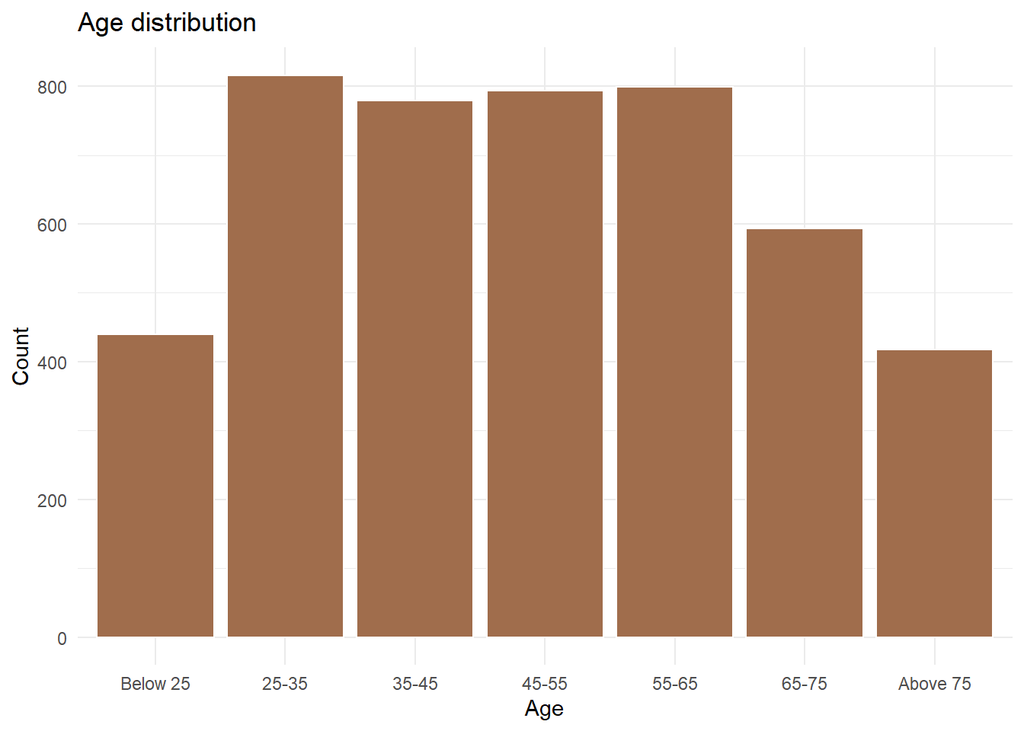

```r
final %>%
  filter(!is.na(AGE)) %>%
  ggplot(mapping = aes(x = AGE)) +
  geom_bar(fill = "#a06d4c", color = "white") +
  labs(title = "Age distribution",
       x = "Age",
       y = "Count") +
  theme_minimal()
```

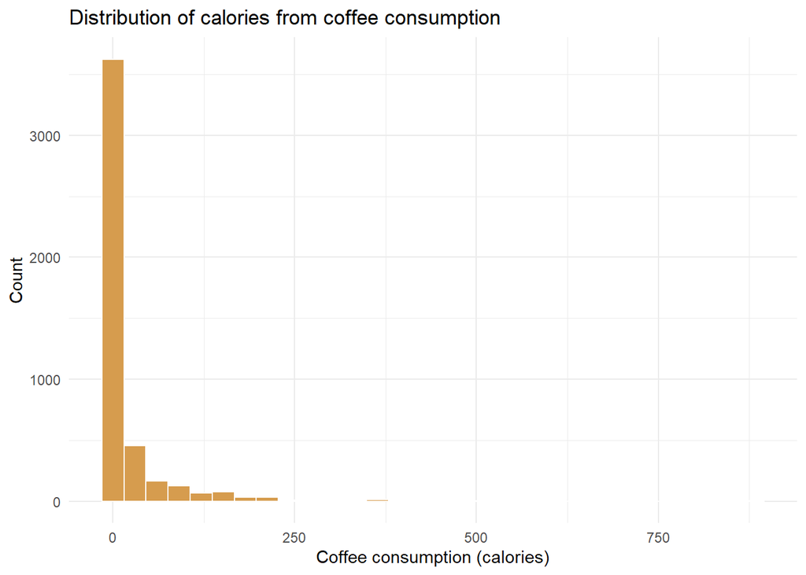

```r
final %>%
  ggplot(mapping = aes(x = COFFEE_TOTAL)) +
  geom_histogram(fill = "#D69C4E", color = "white") +
  labs(title = "Distribution of calories from coffee consumption",
       x = "Coffee consumption (calories)",
       y = "Count") +
  theme_minimal()
```

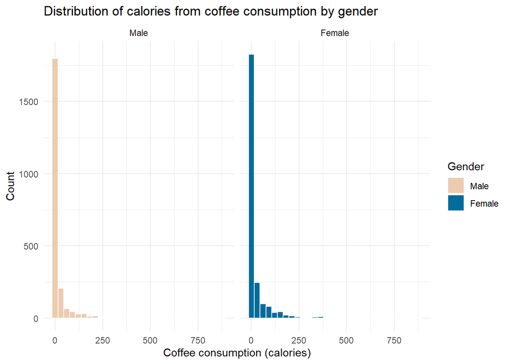

```r
final %>%
  ggplot() +
  geom_histogram(mapping = aes(x = COFFEE_TOTAL, fill = GENDER), color = "white") +
  labs(title = "Distribution of calories from coffee consumption by gender",
       x = "Coffee consumption (calories)",
       y = "Count") +
  scale_fill_manual(name = "Gender", values = wes_palette("Darjeeling2")) +
  facet_wrap(~ GENDER) +
  theme_minimal()
```

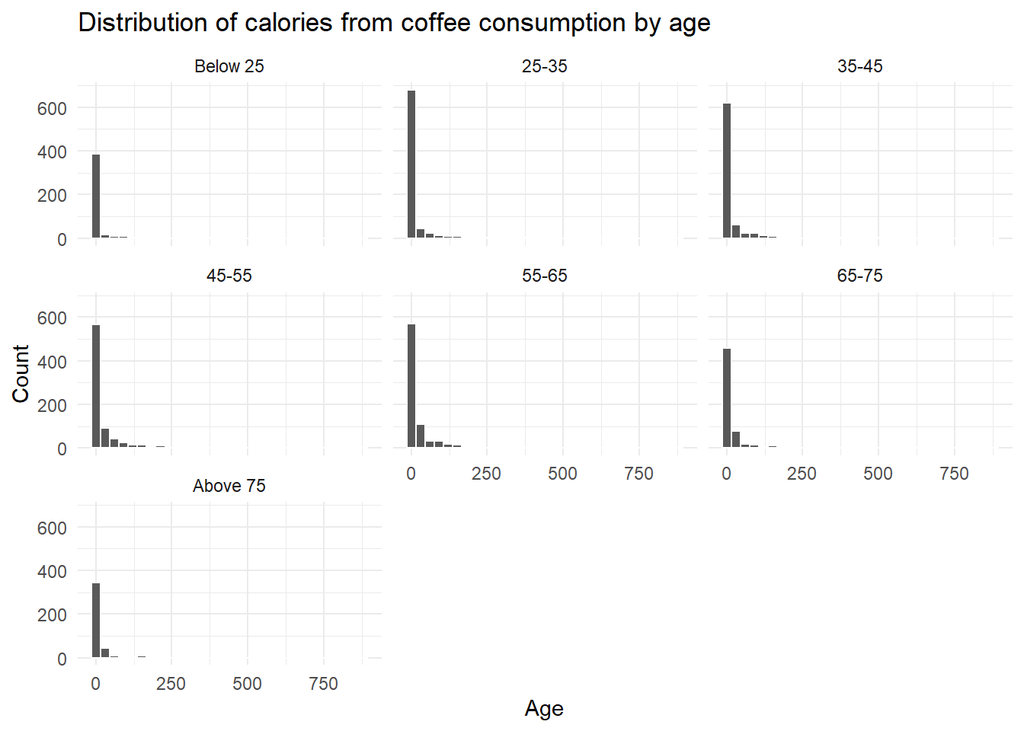

```r
final %>%
  ggplot() +
  geom_histogram(mapping = aes(x = COFFEE_TOTAL), color = "white") +
  labs(title = "Distribution of calories from coffee consumption by age",
       x = "Age",
       y = "Count") +
  #scale_fill_manual(name = "Coffee consumption (calories)", values = wes_palette("Moonrise2")) +
  facet_wrap(~ AGE) +
  theme_minimal()
```

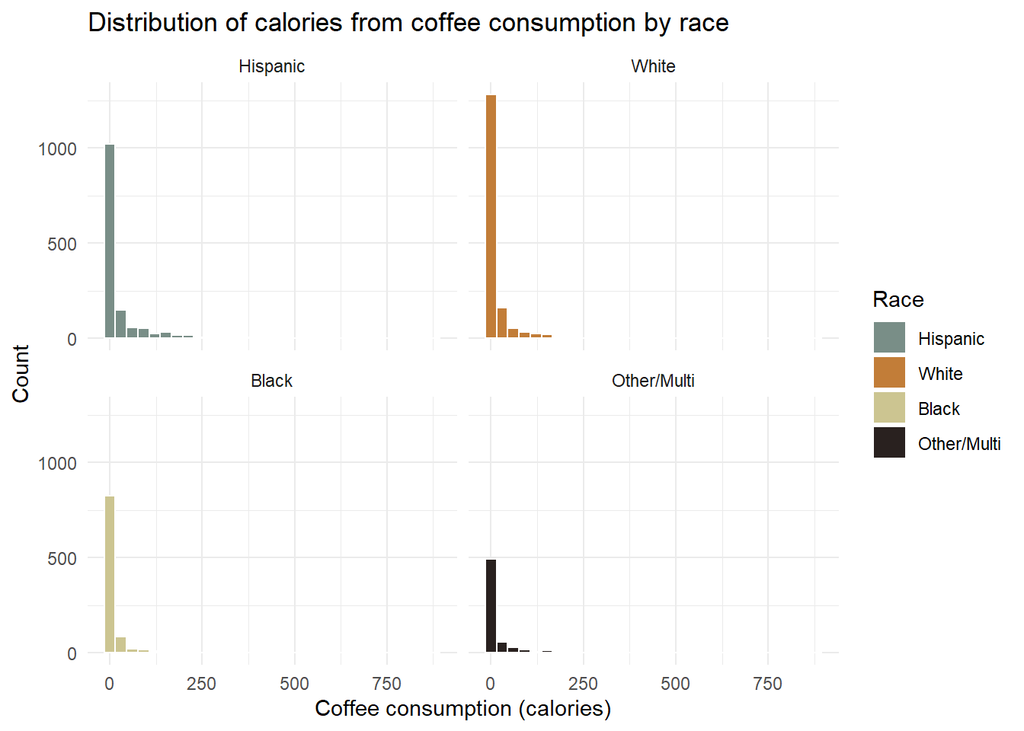

```r
final %>%
  ggplot() +
  geom_histogram(mapping = aes(x = COFFEE_TOTAL, fill = RACE), color = "white") +
  labs(title = "Distribution of calories from coffee consumption by race",
       x = "Coffee consumption (calories)",
       y = "Count") +
  scale_fill_manual(name = "Race", values = wes_palette("Moonrise2")) +
  facet_wrap(~ RACE) +
  theme_minimal()
```

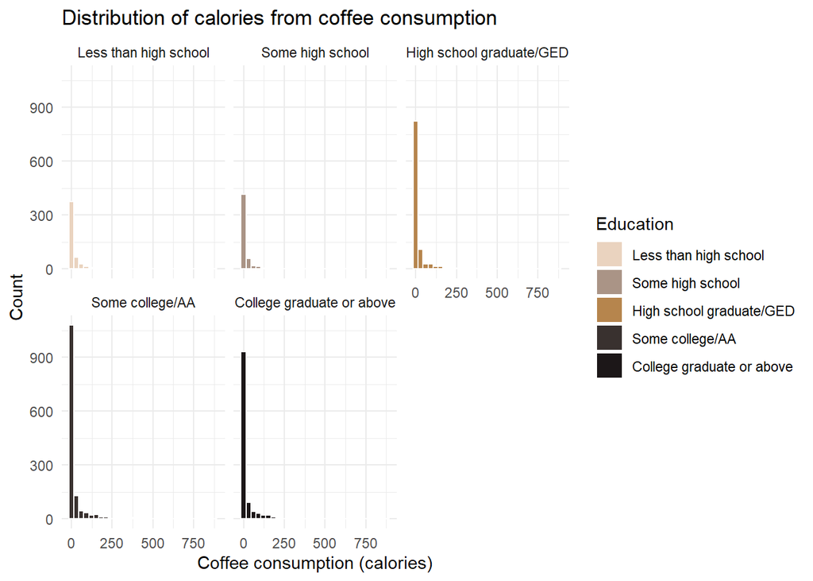

```r
final %>%
  filter(!(EDUCATION == "Unsure" | is.na(EDUCATION))) %>%
  ggplot() +
  geom_histogram(mapping = aes(x = COFFEE_TOTAL, fill = EDUCATION), color = "white") +
  labs(title = "Distribution of calories from coffee consumption",
       x = "Coffee consumption (calories)",
       y = "Count") +
  scale_fill_manual(name = "Education", values = wes_palette("IsleofDogs2")) +
  facet_wrap(~ EDUCATION) +
  theme_minimal()
```

# 4. Data Analysis

```r
summary(final)
```

```
##       SEQN           TOTAL        COFFEE_TOTAL       GENDER
##  Min.   :83732   Min.   :  110   Min.   :  0.00   Male  :2224
##  1st Qu.:86156   1st Qu.: 1441   1st Qu.:  0.00   Female:2413
##  Median :88673   Median : 1939   Median :  1.00
##  Mean   :88681   Mean   : 2084   Mean   : 21.14
##  3rd Qu.:91177   3rd Qu.: 2559   3rd Qu.: 12.00
##  Max.   :93702   Max.   :10126   Max.   :880.00
##
##        AGE               RACE                          EDUCATION
##  Below 25:440   Hispanic   :1402   Less than high school    : 507
##  25-35   :816   White      :1615   Some high school         : 526
##  35-45   :779   Black      : 984   High school graduate/GED :1042
##  45-55   :793   Other/Multi: 636   Some college/AA          :1390
##  55-65   :799                      College graduate or above:1170
##  65-75   :593                      Unsure                   :   2
##  Above 75:417
##                 MARITAL        HH_SIZE            HH_INC
##  Married            :2384   Min.   :1.000   Below 20k: 892
##  Never married      : 829   1st Qu.:2.000   20-45k   :1328
##  Divorced           : 497   Median :3.000   45-75k   : 961
##  Living with partner: 441   Mean   :3.226   Above 75k:1294
##  Widowed            : 326   3rd Qu.:4.000   Refused  :  84
##  Separated          : 159   Max.   :7.000   Unsure   :  78
##  (Other)            :   1
```

```r
final[which.max(final$COFFEE_TOTAL), ]
```

```
## # A tibble: 1 x 10
##    SEQN TOTAL COFFEE_TOTAL GENDER AGE   RACE  EDUCATION MARITAL HH_SIZE
##   <dbl> <dbl>        <dbl> <fct>  <fct> <fct> <fct>     <fct>     <dbl>
## 1 93274  2178          880 Female Belo~ White Some col~ Living~       2
## # ... with 1 more variable: HH_INC <fct>
```

```r
tapply(final$TOTAL, final$GENDER, mean, na.rm = T)
```

```
##     Male   Female
## 2387.881 1804.446
```

```r
tapply(final$COFFEE_TOTAL, final$GENDER, mean, na.rm = T)
```

```
##     Male   Female
## 18.35117 23.70700
```

```r
tapply(final$TOTAL, final$EDUCATION, mean, na.rm = T)
```

```
##     Less than high school          Some high school
##                  1842.799                  2109.405
##  High school graduate/GED           Some college/AA
##                  2106.241                  2111.486
## College graduate or above                    Unsure
##                  2127.022                  1322.500
```

```r
tapply(final$COFFEE_TOTAL, final$EDUCATION, mean, na.rm = T)
```

```
##     Less than high school          Some high school
##                  20.52071                  16.19202
##  High school graduate/GED           Some college/AA
##                  19.65547                  25.69568
## College graduate or above                    Unsure
##                  19.35470                 127.00000
```

```r
tapply(final$TOTAL, final$RACE, mean, na.rm = T)
```

```
##    Hispanic       White       Black Other/Multi
##    2095.919    2138.897    2032.581    1999.871
```

```r
tapply(final$COFFEE_TOTAL, final$RACE, mean, na.rm = T)
```

```
##    Hispanic       White       Black Other/Multi
##    26.39586    21.27678    11.95020    23.41195
```

```r
final %>%
  t.test(COFFEE_TOTAL ~ GENDER, data = ., var.equal = TRUE)
```

```
##
##  Two Sample t-test
##
## data:  COFFEE_TOTAL by GENDER
## t = -3.1693, df = 4635, p-value = 0.001538
## alternative hypothesis: true difference in means is not equal to 0
## 95 percent confidence interval:
##  -8.668876 -2.042794
## sample estimates:
##   mean in group Male mean in group Female
##             18.35117             23.70700
```

# 5. Linear Regression

```r
reg <- glm(COFFEE_TOTAL ~ GENDER + AGE + RACE + EDUCATION + MARITAL + HH_SIZE + HH_INC, data = final)
summary(reg)
```

```
##
## Call:
## glm(formula = COFFEE_TOTAL ~ GENDER + AGE + RACE + EDUCATION +
##     MARITAL + HH_SIZE + HH_INC, data = final)
##
## Deviance Residuals:
##     Min       1Q   Median       3Q      Max
## -121.22   -22.77   -14.97    -4.00   851.25
##
## Coefficients:
##                                    Estimate Std. Error t value Pr(>|t|)
## (Intercept)                         21.2494     5.4838   3.875 0.000108
## GENDERFemale                         5.2587     1.7092   3.077 0.002105
## AGE25-35                             2.5704     3.5155   0.731 0.464715
## AGE35-45                             4.6183     3.6786   1.255 0.209375
## AGE45-55                             8.7523     3.7632   2.326 0.020075
## AGE55-65                             6.8677     3.8412   1.788 0.073858
## AGE65-75                            -2.9139     4.1467  -0.703 0.482270
## AGEAbove 75                         -5.2690     4.6560  -1.132 0.257838
## RACEWhite                           -5.4373     2.3099  -2.354 0.018617
## RACEBlack                          -15.0218     2.5107  -5.983 2.35e-09
## RACEOther/Multi                     -3.0075     2.8781  -1.045 0.296105
## EDUCATIONSome high school           -1.9818     3.6328  -0.546 0.585415
## EDUCATIONHigh school graduate/GED    2.3689     3.2867   0.721 0.471097
## EDUCATIONSome college/AA             7.6271     3.2578   2.341 0.019264
## EDUCATIONCollege graduate or above  -0.4328     3.5354  -0.122 0.902571
## EDUCATIONUnsure                    113.7727    40.4531   2.812 0.004937
## MARITALWidowed                      -3.1524     3.7896  -0.832 0.405536
## MARITALDivorced                      2.5729     2.9671   0.867 0.385910
## MARITALSeparated                    -2.4670     4.7765  -0.517 0.605529
## MARITALNever married                -6.2624     2.7022  -2.318 0.020519
## MARITALLiving with partner           1.4866     3.1104   0.478 0.632704
## MARITALRefused                     143.3203    57.0501   2.512 0.012033
## HH_SIZE                             -0.7175     0.5825  -1.232 0.218101
## HH_INC20-45k                        -1.7924     2.5500  -0.703 0.482148
## HH_INC45-75k                         1.4199     2.8424   0.500 0.617427
## HH_INCAbove 75k                      1.9607     2.8894   0.679 0.497446
## HH_INCRefused                        0.6666     6.5862   0.101 0.919382
## HH_INCUnsure                         0.1792     6.7476   0.027 0.978819
##
```

[output cut: 23 more lines]

```
## HH_INC20-45k
## HH_INC45-75k
## HH_INCAbove 75k
## HH_INCRefused
## HH_INCUnsure
## ---
## Signif. codes:  0 '***' 0.001 '**' 0.01 '*' 0.05 '.' 0.1 ' ' 1
##
## (Dispersion parameter for gaussian family taken to be 3240.839)
##
##     Null deviance: 15352372  on 4636  degrees of freedom
## Residual deviance: 14937025  on 4609  degrees of freedom
## AIC: 50673
##
## Number of Fisher Scoring iterations: 2
```

```r
reg2 <- glm(COFFEE_TOTAL ~ GENDER + AGE + RACE + EDUCATION, data = final)
summary(reg2)
```

```
##
## Call:
## glm(formula = COFFEE_TOTAL ~ GENDER + AGE + RACE + EDUCATION,
##     data = final)
##
## Deviance Residuals:
##     Min       1Q   Median       3Q      Max
## -122.92   -22.91   -15.41    -4.48   857.05
##
## Coefficients:
##                                    Estimate Std. Error t value Pr(>|t|)
## (Intercept)                          13.942      3.933   3.545 0.000396
## GENDERFemale                          4.929      1.683   2.929 0.003421
## AGE25-35                              5.196      3.386   1.535 0.124961
## AGE35-45                              8.195      3.414   2.400 0.016430
## AGE45-55                             12.956      3.401   3.809 0.000141
## AGE55-65                             11.152      3.407   3.273 0.001070
## AGE65-75                              1.469      3.621   0.406 0.684915
## AGEAbove 75                          -1.766      3.981  -0.444 0.657418
## RACEWhite                            -4.937      2.256  -2.189 0.028674
## RACEBlack                           -15.936      2.464  -6.467  1.1e-10
## RACEOther/Multi                      -2.952      2.860  -1.032 0.301928
## EDUCATIONSome high school            -1.721      3.625  -0.475 0.635021
## EDUCATIONHigh school graduate/GED     3.172      3.243   0.978 0.328116
## EDUCATIONSome college/AA              9.020      3.163   2.852 0.004366
## EDUCATIONCollege graduate or above    1.628      3.289   0.495 0.620547
## EDUCATIONUnsure                     110.742     40.392   2.742 0.006137
##
## (Intercept)                        ***
## GENDERFemale                       **
## AGE25-35
## AGE35-45                           *
## AGE45-55                           ***
## AGE55-65                           **
## AGE65-75
## AGEAbove 75
## RACEWhite                          *
## RACEBlack                          ***
## RACEOther/Multi
## EDUCATIONSome high school
## EDUCATIONHigh school graduate/GED
## EDUCATIONSome college/AA           **
## EDUCATIONCollege graduate or above
## EDUCATIONUnsure                    **
## ---
## Signif. codes:  0 '***' 0.001 '**' 0.01 '*' 0.05 '.' 0.1 ' ' 1
##
## (Dispersion parameter for gaussian family taken to be 3245.616)
##
##     Null deviance: 15352372  on 4636  degrees of freedom
## Residual deviance: 14997993  on 4621  degrees of freedom
## AIC: 50668
##
## Number of Fisher Scoring iterations: 2
```

```r
tony <- data.frame(
  GENDER = "Male",
  AGE = "Below 25",
  RACE = "Other/Multi",
  EDUCATION = "College graduate or above"
  )
```

```r
predict(reg2, newdata = tony)
```

```
##        1
## 12.61799
```

# Bonus

```r
diet <- read.xport("DR1IFF_I.XPT")

diet <- diet %>%
  select(SEQN, KCAL = DR1IKCAL, GRAMS = DR1IGRMS, USDA = DR1IFDCD)

avgkcal <- right_join(diet, coffee_code, by = "USDA") %>%
  group_by(USDA) %>%
  mutate(AVGKCAL = mean(KCAL / GRAMS) * mean(GRAMS)) %>%
  select(USDA, AVGKCAL, SHORT, LONG) %>%
  distinct(.) %>%
  arrange(-(AVGKCAL))

right_join(diet, coffee_code, by = "USDA") %>%
  group_by(USDA) %>%
  mutate(AVGKCAL = mean(KCAL)) %>%
  select(USDA, AVGKCAL, SHORT, LONG) %>%
  distinct(.) %>%
  arrange(-(AVGKCAL))
```

```
## # A tibble: 135 x 4
## # Groups:   USDA [135]
##       USDA AVGKCAL SHORT                        LONG
##      <dbl>   <dbl> <fct>                        <fct>
##  1  9.21e7    453  FROZEN MOCHA COFFEE DRINK, ~ Frozen mocha coffee drink,~
##  2  9.21e7    348  COFFEE, LATTE, WITH NON-DAI~ Coffee, Latte, with non-da~
##  3  9.21e7    329. FROZEN COFFEE DRINK, WITH W~ Frozen coffee drink, with ~
##  4  9.22e7    274. COFFEE, BOTTLED/CANNED       Coffee, bottled/canned
##  5  9.21e7    272. FROZEN COFFEE DRINK          Frozen coffee drink
##  6  9.21e7    270. COFFEE, ICED CAFE MOCHA      Coffee, Iced Cafe Mocha
##  7  9.21e7    268. COFFEE, LATTE, DECAFFEINATE~ Coffee, Latte, decaffeinat~
##  8  9.21e7    261. COFFEE, CAFE MOCHA           Coffee, Cafe Mocha
##  9  9.21e7    260  FROZEN MOCHA COFFEE DRINK, ~ Frozen mocha coffee drink,~
## 10  9.21e7    221  FROZEN COFFEE DRINK, NONFAT  Frozen coffee drink, nonfat
## # ... with 125 more rows
```